# Pandas_Intro

**AUTHOR : SUBHAM TEWARI**

ALL COPYRIGHTS RESERVED

Pandas

*pandas* is a Python library for data analysis. It offers a number of data exploration, cleaning and transformation operations that are critical in working with data in Python.

*pandas* build upon *numpy* and *scipy* providing easy-to-use data structures and data manipulation functions with integrated indexing.

The main data structures *pandas* provides are *Series* and *DataFrames*. After a brief introduction to these two data structures and data ingestion, the key features of *pandas* this notebook covers are:

- Generating descriptive statistics on data
- Data cleaning using built in pandas functions
- Frequent data operations for subsetting, filtering, insertion, deletion and aggregation of data
- Merging multiple datasets using dataframes
- Working with timestamps and time-series data

**Additional Recommended Resources:**

- *pandas* Documentation: http://pandas.pydata.org/pandas-docs/stable/
- *Python for Data Analysis* by Wes McKinney
- *Python Data Science Handbook* by Jake VanderPlas

Let's get started with our first *pandas* notebook!

Import Libraries

```python
import pandas as pd
```

Introduction to pandas Data Structures

*pandas* has two main data structures it uses, namely, *Series* and *DataFrames*.

pandas Series

*pandas Series* one-dimensional labeled array.

```python
ser = pd.Series(data=[100, 'foo', 300, 'bar', 500],index=['tom', 'bob', 'nancy', 'dan', 'eric']) # Note that series is a 1D array type of data structure which can take heterogenous types of data
```

```python
ser
```

```
tom      100
bob      foo
nancy    300
dan      bar
eric     500
dtype: object
```

```python
ser.index
```

```
Index(['tom', 'bob', 'nancy', 'dan', 'eric'], dtype='object')
```

```python
ser['nancy'] # So you can access the value of any index of series
#ser.loc['nancy'] also gives the same output
```

```
300
```

```python
ser[[4, 3, 1]] # So returns the series at indices four,three and one
```

```
eric    500
dan     bar
bob     foo
dtype: object
```

```python
ser.iloc[2] # Returns the value at the index 2
```

```
300
```

```python
'bob' in ser # Check if the word bob is present in the series bob
```

```
True
```

```python
ser*2 # So we multiply the whole series with two. Note that the string is also multiplied by 2 means it repeats itself twice
```

```
tom         200
bob      foofoo
nancy       600
dan      barbar
eric       1000
dtype: object
```

```python
ser[['nancy', 'eric']] ** 2 # Note that it does the square of the values . It is not applicable for the strings
#ser ** 2 # It will raise an error
```

```
nancy     90000
eric     250000
dtype: object
```

pandas DataFrame

*pandas DataFrame* is a 2-dimensional labeled data structure.

Create DataFrame from dictionary of Python Series

```python
d = {'one' : pd.Series([100., 200., 300.], index=['apple', 'ball', 'clock']),
     'two' : pd.Series([111., 222., 333., 4444.], index=['apple', 'ball', 'cerill', 'dancy'])}
```

```python
df = pd.DataFrame(d)
print(df)
```

```
          one     two
apple   100.0   111.0
ball    200.0   222.0
cerill    NaN   333.0
clock   300.0     NaN
dancy     NaN  4444.0
```

```python
df.index
```

```
Index(['apple', 'ball', 'cerill', 'clock', 'dancy'], dtype='object')
```

```python
df.columns
```

```
Index(['one', 'two'], dtype='object')
```

```python
pd.DataFrame(d, index=['dancy', 'ball', 'apple'])
```

|  | one | two |
| --- | --- | --- |
| dancy | NaN | 4444.0 |
| ball | 200.0 | 222.0 |
| apple | 100.0 | 111.0 |

```python
pd.DataFrame(d, index=['dancy', 'ball', 'apple'], columns=['two', 'five']) # Note as the column five doesn't exist it has also the values as NaN in those indices
```

|  | two | five |
| --- | --- | --- |
| dancy | 4444.0 | NaN |
| ball | 222.0 | NaN |
| apple | 111.0 | NaN |

Create DataFrame from list of Python dictionaries

```python
data = [{'alex': 1, 'joe': 2}, {'ema': 5, 'dora': 10, 'alice': 20}]
```

```python
pd.DataFrame(data)
```

|  | alex | alice | dora | ema | joe |
| --- | --- | --- | --- | --- | --- |
| 0 | 1.0 | NaN | NaN | NaN | 2.0 |
| 1 | NaN | 20.0 | 10.0 | 5.0 | NaN |

```python
pd.DataFrame(data, index=['orange', 'red'])
```

|  | alex | alice | dora | ema | joe |
| --- | --- | --- | --- | --- | --- |
| orange | 1.0 | NaN | NaN | NaN | 2.0 |
| red | NaN | 20.0 | 10.0 | 5.0 | NaN |

```python
pd.DataFrame(data, columns=['joe', 'dora','alice'])
```

|  | joe | dora | alice |
| --- | --- | --- | --- |
| 0 | 2.0 | NaN | NaN |
| 1 | NaN | 10.0 | 20.0 |

Basic DataFrame operations

```python
df
```

|  | one | two |
| --- | --- | --- |
| apple | 100.0 | 111.0 |
| ball | 200.0 | 222.0 |
| cerill | NaN | 333.0 |
| clock | 300.0 | NaN |
| dancy | NaN | 4444.0 |

```python
df['one']
```

```
apple     100.0
ball      200.0
cerill      NaN
clock     300.0
dancy       NaN
Name: one, dtype: float64
```

```python
df['three'] = df['one'] * df['two']
df
```

|  | one | two | three |
| --- | --- | --- | --- |
| apple | 100.0 | 111.0 | 11100.0 |
| ball | 200.0 | 222.0 | 44400.0 |
| cerill | NaN | 333.0 | NaN |
| clock | 300.0 | NaN | NaN |
| dancy | NaN | 4444.0 | NaN |

```python
df['flag'] = df['one'] > 250
df
```

|  | one | two | three | flag |
| --- | --- | --- | --- | --- |
| apple | 100.0 | 111.0 | 11100.0 | False |
| ball | 200.0 | 222.0 | 44400.0 | False |
| cerill | NaN | 333.0 | NaN | False |
| clock | 300.0 | NaN | NaN | True |
| dancy | NaN | 4444.0 | NaN | False |

```python
three = df.pop('three')
```

```python
three
```

```
apple     11100.0
ball      44400.0
cerill        NaN
clock         NaN
dancy         NaN
Name: three, dtype: float64
```

```python
df
```

|  | one | two | flag |
| --- | --- | --- | --- |
| apple | 100.0 | 111.0 | False |
| ball | 200.0 | 222.0 | False |
| cerill | NaN | 333.0 | False |
| clock | 300.0 | NaN | True |
| dancy | NaN | 4444.0 | False |

```python
del df['two']
```

```python
df
```

|  | one | flag |
| --- | --- | --- |
| apple | 100.0 | False |
| ball | 200.0 | False |
| cerill | NaN | False |
| clock | 300.0 | True |
| dancy | NaN | False |

```python
df.insert(2, 'copy_of_one', df['one'])
df
```

|  | one | flag | copy_of_one |
| --- | --- | --- | --- |
| apple | 100.0 | False | 100.0 |
| ball | 200.0 | False | 200.0 |
| cerill | NaN | False | NaN |
| clock | 300.0 | True | 300.0 |
| dancy | NaN | False | NaN |

```python
df['one_upper_half'] = df['one'][:2]
df
```

|  | one | flag | copy_of_one | one_upper_half |
| --- | --- | --- | --- | --- |
| apple | 100.0 | False | 100.0 | 100.0 |
| ball | 200.0 | False | 200.0 | 200.0 |
| cerill | NaN | False | NaN | NaN |
| clock | 300.0 | True | 300.0 | NaN |
| dancy | NaN | False | NaN | NaN |

Case Study: Movie Data Analysis

This notebook uses a dataset from the MovieLens website. We will describe the dataset further as we explore with it using *pandas*.

## Download the Dataset

Please note that **you will need to download the dataset**.

Here are the links to the data source and location:

- **Data Source:** MovieLens web site (filename: ml-20m.zip)
- **Location:** https://grouplens.org/datasets/movielens/

Once the download completes, please make sure the data files are in a directory called *movielens* in your *Week-3-pandas* folder.

Let us look at the files in this dataset using the UNIX command ls.

```python
# Note: Adjust the name of the folder to match your local directory

!ls ./movielens
```

```
genome-scores.csv  links.csv   ratings.csv  tags.csv
genome-tags.csv    movies.csv  README.txt
```

```python
!cat ./movielens/movies.csv | wc -l
```

```
27279
```

```python
!head -5 ./movielens/ratings.csv
```

[output not shown]

Use Pandas to Read the Dataset

In this notebook, we will be using three CSV files:

- **ratings.csv :** *userId*,*movieId*,*rating*, *timestamp*
- **tags.csv :** *userId*,*movieId*, *tag*, *timestamp*
- **movies.csv :** *movieId*, *title*, *genres*

Using the *read_csv* function in pandas, we will ingest these three files.

```python
movies = pd.read_csv('./movielens/movies.csv', sep=',')
print(type(movies))
movies.head(15)
```

```
<class 'pandas.core.frame.DataFrame'>
```

|  | movieId | title | genres |
| --- | --- | --- | --- |
| 0 | 1 | Toy Story (1995) | Adventure\|Animation\|Children\|Comedy\|Fantasy |
| 1 | 2 | Jumanji (1995) | Adventure\|Children\|Fantasy |
| 2 | 3 | Grumpier Old Men (1995) | Comedy\|Romance |
| 3 | 4 | Waiting to Exhale (1995) | Comedy\|Drama\|Romance |
| 4 | 5 | Father of the Bride Part II (1995) | Comedy |
| 5 | 6 | Heat (1995) | Action\|Crime\|Thriller |
| 6 | 7 | Sabrina (1995) | Comedy\|Romance |
| 7 | 8 | Tom and Huck (1995) | Adventure\|Children |
| 8 | 9 | Sudden Death (1995) | Action |
| 9 | 10 | GoldenEye (1995) | Action\|Adventure\|Thriller |
| 10 | 11 | American President, The (1995) | Comedy\|Drama\|Romance |
| 11 | 12 | Dracula: Dead and Loving It (1995) | Comedy\|Horror |
| 12 | 13 | Balto (1995) | Adventure\|Animation\|Children |
| 13 | 14 | Nixon (1995) | Drama |
| 14 | 15 | Cutthroat Island (1995) | Action\|Adventure\|Romance |

```python
# Timestamps represent seconds since midnight Coordinated Universal Time (UTC) of January 1, 1970

tags = pd.read_csv('./movielens/tags.csv', sep=',')
tags.head()
```

|  | userId | movieId | tag | timestamp |
| --- | --- | --- | --- | --- |
| 0 | 18 | 4141 | Mark Waters | 1240597180 |
| 1 | 65 | 208 | dark hero | 1368150078 |
| 2 | 65 | 353 | dark hero | 1368150079 |
| 3 | 65 | 521 | noir thriller | 1368149983 |
| 4 | 65 | 592 | dark hero | 1368150078 |

```python
ratings = pd.read_csv('./movielens/ratings.csv', sep=',', parse_dates=['timestamp'])
ratings.head()
```

|  | userId | movieId | rating | timestamp |
| --- | --- | --- | --- | --- |
| 0 | 1 | 2 | 3.5 | 1112486027 |
| 1 | 1 | 29 | 3.5 | 1112484676 |
| 2 | 1 | 32 | 3.5 | 1112484819 |
| 3 | 1 | 47 | 3.5 | 1112484727 |
| 4 | 1 | 50 | 3.5 | 1112484580 |

```python
# For current analysis, we will remove timestamp (we will come back to it!)

del ratings['timestamp']
del tags['timestamp']
```

# Series

```python
#Extract 0th row: notice that it is infact a Series

row_0 = tags.iloc[0]
type(row_0)
```

```
pandas.core.series.Series
```

```python
print(row_0)
```

```
userId              18
movieId           4141
tag        Mark Waters
Name: 0, dtype: object
```

```python
row_0.index
```

```
Index(['userId', 'movieId', 'tag'], dtype='object')
```

```python
row_0['userId']
```

```
18
```

```python
'rating' in row_0
```

```
False
```

```python
row_0.name
```

```
0
```

```python
row_0 = row_0.rename('first_row')
row_0.name
```

```
'first_row'
```

# DataFrames

```python
tags.head()
```

|  | userId | movieId | tag |
| --- | --- | --- | --- |
| 0 | 18 | 4141 | Mark Waters |
| 1 | 65 | 208 | dark hero |
| 2 | 65 | 353 | dark hero |
| 3 | 65 | 521 | noir thriller |
| 4 | 65 | 592 | dark hero |

```python
tags.index
```

```
RangeIndex(start=0, stop=465564, step=1)
```

```python
tags.columns
```

```
Index(['userId', 'movieId', 'tag'], dtype='object')
```

```python
# Extract row 0, 11, 2000 from DataFrame

tags.iloc[ [0,11,2000] ]
```

|  | userId | movieId | tag |
| --- | --- | --- | --- |
| 0 | 18 | 4141 | Mark Waters |
| 11 | 65 | 1783 | noir thriller |
| 2000 | 910 | 68554 | conspiracy theory |

# Descriptive Statistics

Let's look how the ratings are distributed!

```python
ratings['rating'].describe()
```

```
count    2.000026e+07
mean     3.525529e+00
std      1.051989e+00
min      5.000000e-01
25%      3.000000e+00
50%      3.500000e+00
75%      4.000000e+00
max      5.000000e+00
Name: rating, dtype: float64
```

```python
ratings.describe()
```

|  | userId | movieId | rating |
| --- | --- | --- | --- |
| count | 2.000026e+07 | 2.000026e+07 | 2.000026e+07 |
| mean | 6.904587e+04 | 9.041567e+03 | 3.525529e+00 |
| std | 4.003863e+04 | 1.978948e+04 | 1.051989e+00 |
| min | 1.000000e+00 | 1.000000e+00 | 5.000000e-01 |
| 25% | 3.439500e+04 | 9.020000e+02 | 3.000000e+00 |
| 50% | 6.914100e+04 | 2.167000e+03 | 3.500000e+00 |
| 75% | 1.036370e+05 | 4.770000e+03 | 4.000000e+00 |
| max | 1.384930e+05 | 1.312620e+05 | 5.000000e+00 |

```python
ratings['rating'].mean()
```

```
3.5255285642993797
```

```python
ratings.mean()
```

```
userId     69045.872583
movieId     9041.567330
rating         3.525529
dtype: float64
```

```python
ratings['rating'].min()
```

```
0.5
```

```python
ratings['rating'].max()
```

```
5.0
```

```python
ratings['rating'].std()
```

```
1.0519889192942424
```

```python
ratings['rating'].mode()
```

```
0    4.0
dtype: float64
```

```python
ratings.corr()
```

|  | userId | movieId | rating |
| --- | --- | --- | --- |
| userId | 1.000000 | -0.000850 | 0.001175 |
| movieId | -0.000850 | 1.000000 | 0.002606 |
| rating | 0.001175 | 0.002606 | 1.000000 |

```python
filter_1 = ratings['rating'] > 5
print(filter_1)
filter_1.any()
```

```
0           False
1           False
2           False
3           False
4           False
5           False
6           False
7           False
8           False
9           False
10          False
11          False
12          False
13          False
14          False
```

[output cut: 47 more lines]

```
False
```

```python
filter_2 = ratings['rating'] > 0
filter_2.all()
```

```
True
```

# Data Cleaning: Handling Missing Data

```python
movies.shape
```

```
(27278, 3)
```

```python
#is any row NULL ?

movies.isnull().any()
```

```
movieId    False
title      False
genres     False
dtype: bool
```

Thats nice ! No NULL values !

```python
ratings.shape
```

```
(20000263, 3)
```

```python
tags.shape
```

```
(465564, 3)
```

```python
#is any row NULL ?

tags.isnull().any()
```

```
userId     False
movieId    False
tag         True
dtype: bool
```

We have some tags which are NULL.

```python
tags = tags.dropna()
```

```python
#Check again: is any row NULL ?

tags.isnull().any()
```

```
userId     False
movieId    False
tag        False
dtype: bool
```

```python
tags.shape
```

```
(465548, 3)
```

Thats nice ! No NULL values ! Notice the number of lines have reduced.

# Data Visualization

```
array([[<matplotlib.axes._subplots.AxesSubplot object at 0x7f6f7b31c4a8>]], dtype=object)
```

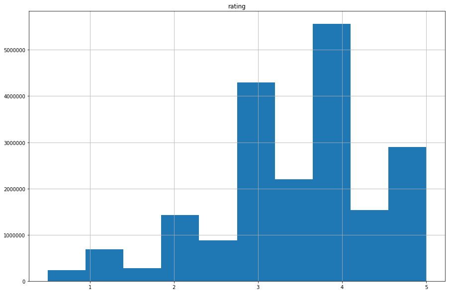

```python
%matplotlib inline

ratings.hist(column='rating', figsize=(15,10))
```

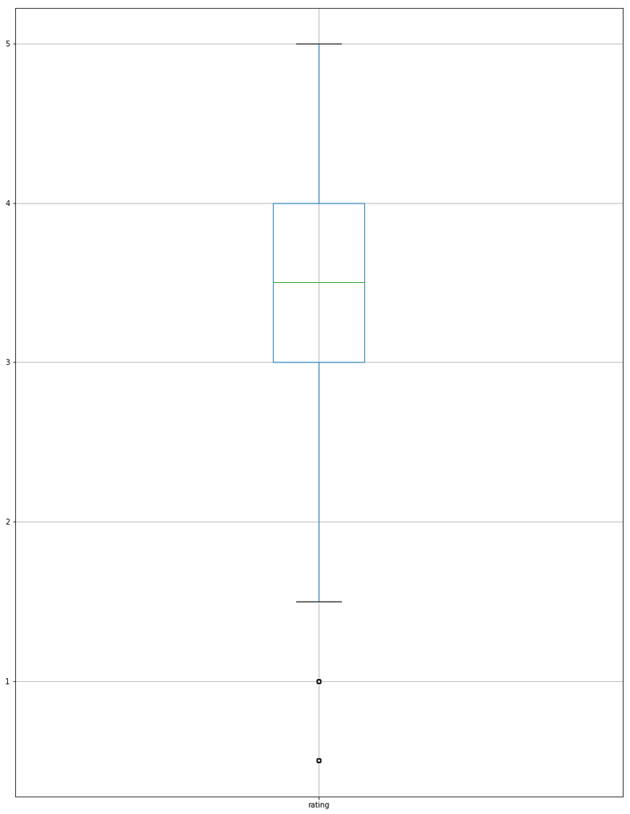

```python
ratings.boxplot(column='rating', figsize=(15,20))
```

# Slicing Out Columns

```python
tags['tag'].head()
```

```
0      Mark Waters
1        dark hero
2        dark hero
3    noir thriller
4        dark hero
Name: tag, dtype: object
```

```python
movies[['title','genres']].head()
```

|  | title | genres |
| --- | --- | --- |
| 0 | Toy Story (1995) | Adventure\|Animation\|Children\|Comedy\|Fantasy |
| 1 | Jumanji (1995) | Adventure\|Children\|Fantasy |
| 2 | Grumpier Old Men (1995) | Comedy\|Romance |
| 3 | Waiting to Exhale (1995) | Comedy\|Drama\|Romance |
| 4 | Father of the Bride Part II (1995) | Comedy |

```python
ratings[-10:]
```

|  | userId | movieId | rating |
| --- | --- | --- | --- |
| 20000253 | 138493 | 60816 | 4.5 |
| 20000254 | 138493 | 61160 | 4.0 |
| 20000255 | 138493 | 65682 | 4.5 |
| 20000256 | 138493 | 66762 | 4.5 |
| 20000257 | 138493 | 68319 | 4.5 |
| 20000258 | 138493 | 68954 | 4.5 |
| 20000259 | 138493 | 69526 | 4.5 |
| 20000260 | 138493 | 69644 | 3.0 |
| 20000261 | 138493 | 70286 | 5.0 |
| 20000262 | 138493 | 71619 | 2.5 |

```python
tag_counts = tags['tag'].value_counts()
tag_counts[-10:]
```

```
WRONGLY COMMITED     1
reality on ending    1
James Strong         1
Highly Quotable      1
22-7-2007            1
Bonnie Bedelia       1
flamingoes           1
Joseph Stantley      1
Off beat             1
horticulture         1
Name: tag, dtype: int64
```

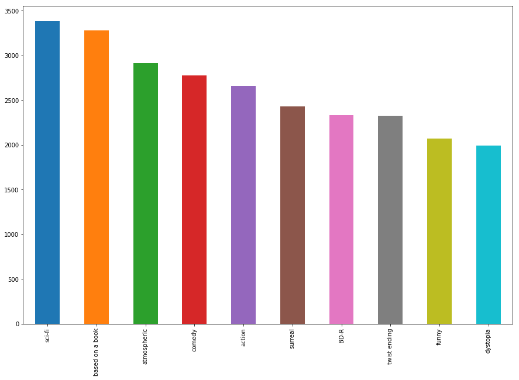

```python
tag_counts[:10].plot(kind='bar', figsize=(15,10))
```

# Filters for Selecting Rows

```python
is_highly_rated = ratings['rating'] >= 4.0

ratings[is_highly_rated][30:50]
```

|  | userId | movieId | rating |
| --- | --- | --- | --- |
| 68 | 1 | 2021 | 4.0 |
| 69 | 1 | 2100 | 4.0 |
| 70 | 1 | 2118 | 4.0 |
| 71 | 1 | 2138 | 4.0 |
| 72 | 1 | 2140 | 4.0 |
| 73 | 1 | 2143 | 4.0 |
| 74 | 1 | 2173 | 4.0 |
| 75 | 1 | 2174 | 4.0 |
| 76 | 1 | 2193 | 4.0 |
| 79 | 1 | 2288 | 4.0 |
| 80 | 1 | 2291 | 4.0 |
| 81 | 1 | 2542 | 4.0 |
| 82 | 1 | 2628 | 4.0 |
| 90 | 1 | 2762 | 4.0 |
| 92 | 1 | 2872 | 4.0 |
| 94 | 1 | 2944 | 4.0 |
| 96 | 1 | 2959 | 4.0 |
| 97 | 1 | 2968 | 4.0 |
| 101 | 1 | 3081 | 4.0 |
| 102 | 1 | 3153 | 4.0 |

```python
is_animation = movies['genres'].str.contains('Animation')

movies[is_animation][5:15]
```

|  | movieId | title | genres |
| --- | --- | --- | --- |
| 310 | 313 | Swan Princess, The (1994) | Animation\|Children |
| 360 | 364 | Lion King, The (1994) | Adventure\|Animation\|Children\|Drama\|Musical\|IMAX |
| 388 | 392 | Secret Adventures of Tom Thumb, The (1993) | Adventure\|Animation |
| 547 | 551 | Nightmare Before Christmas, The (1993) | Animation\|Children\|Fantasy\|Musical |
| 553 | 558 | Pagemaster, The (1994) | Action\|Adventure\|Animation\|Children\|Fantasy |
| 582 | 588 | Aladdin (1992) | Adventure\|Animation\|Children\|Comedy\|Musical |
| 588 | 594 | Snow White and the Seven Dwarfs (1937) | Animation\|Children\|Drama\|Fantasy\|Musical |
| 589 | 595 | Beauty and the Beast (1991) | Animation\|Children\|Fantasy\|Musical\|Romance\|IMAX |
| 590 | 596 | Pinocchio (1940) | Animation\|Children\|Fantasy\|Musical |
| 604 | 610 | Heavy Metal (1981) | Action\|Adventure\|Animation\|Horror\|Sci-Fi |

```python
movies[is_animation].head(15)
```

|  | movieId | title | genres |
| --- | --- | --- | --- |
| 0 | 1 | Toy Story (1995) | Adventure\|Animation\|Children\|Comedy\|Fantasy |
| 12 | 13 | Balto (1995) | Adventure\|Animation\|Children |
| 47 | 48 | Pocahontas (1995) | Animation\|Children\|Drama\|Musical\|Romance |
| 236 | 239 | Goofy Movie, A (1995) | Animation\|Children\|Comedy\|Romance |
| 241 | 244 | Gumby: The Movie (1995) | Animation\|Children |
| 310 | 313 | Swan Princess, The (1994) | Animation\|Children |
| 360 | 364 | Lion King, The (1994) | Adventure\|Animation\|Children\|Drama\|Musical\|IMAX |
| 388 | 392 | Secret Adventures of Tom Thumb, The (1993) | Adventure\|Animation |
| 547 | 551 | Nightmare Before Christmas, The (1993) | Animation\|Children\|Fantasy\|Musical |
| 553 | 558 | Pagemaster, The (1994) | Action\|Adventure\|Animation\|Children\|Fantasy |
| 582 | 588 | Aladdin (1992) | Adventure\|Animation\|Children\|Comedy\|Musical |
| 588 | 594 | Snow White and the Seven Dwarfs (1937) | Animation\|Children\|Drama\|Fantasy\|Musical |
| 589 | 595 | Beauty and the Beast (1991) | Animation\|Children\|Fantasy\|Musical\|Romance\|IMAX |
| 590 | 596 | Pinocchio (1940) | Animation\|Children\|Fantasy\|Musical |
| 604 | 610 | Heavy Metal (1981) | Action\|Adventure\|Animation\|Horror\|Sci-Fi |

# Group By and Aggregate

```python
ratings_count = ratings[['movieId','rating']].groupby('rating').count()
ratings_count
```

| rating | movieId |
| --- | --- |
| 0.5 | 239125 |
| 1.0 | 680732 |
| 1.5 | 279252 |
| 2.0 | 1430997 |
| 2.5 | 883398 |
| 3.0 | 4291193 |
| 3.5 | 2200156 |
| 4.0 | 5561926 |
| 4.5 | 1534824 |
| 5.0 | 2898660 |

```python
average_rating = ratings[['movieId','rating']].groupby('movieId').mean()
average_rating.head()
```

| movieId | rating |
| --- | --- |
| 1 | 3.921240 |
| 2 | 3.211977 |
| 3 | 3.151040 |
| 4 | 2.861393 |
| 5 | 3.064592 |

```python
movie_count = ratings[['movieId','rating']].groupby('movieId').count()
movie_count.tail()
```

| movieId | rating |
| --- | --- |
| 131254 | 1 |
| 131256 | 1 |
| 131258 | 1 |
| 131260 | 1 |
| 131262 | 1 |

# Merge Dataframes

```python
tags.head()
```

|  | userId | movieId | tag |
| --- | --- | --- | --- |
| 0 | 18 | 4141 | Mark Waters |
| 1 | 65 | 208 | dark hero |
| 2 | 65 | 353 | dark hero |
| 3 | 65 | 521 | noir thriller |
| 4 | 65 | 592 | dark hero |

```python
movies.head()
```

|  | movieId | title | genres |
| --- | --- | --- | --- |
| 0 | 1 | Toy Story (1995) | Adventure\|Animation\|Children\|Comedy\|Fantasy |
| 1 | 2 | Jumanji (1995) | Adventure\|Children\|Fantasy |
| 2 | 3 | Grumpier Old Men (1995) | Comedy\|Romance |
| 3 | 4 | Waiting to Exhale (1995) | Comedy\|Drama\|Romance |
| 4 | 5 | Father of the Bride Part II (1995) | Comedy |

```python
t = movies.merge(tags, on='movieId', how='inner') # inner: use intersection of keys from both frames, similar to a SQL inner join; preserve the order of the left keys
t.head()
```

|  | movieId | title | genres | userId | tag |
| --- | --- | --- | --- | --- | --- |
| 0 | 1 | Toy Story (1995) | Adventure\|Animation\|Children\|Comedy\|Fantasy | 1644 | Watched |
| 1 | 1 | Toy Story (1995) | Adventure\|Animation\|Children\|Comedy\|Fantasy | 1741 | computer animation |
| 2 | 1 | Toy Story (1995) | Adventure\|Animation\|Children\|Comedy\|Fantasy | 1741 | Disney animated feature |
| 3 | 1 | Toy Story (1995) | Adventure\|Animation\|Children\|Comedy\|Fantasy | 1741 | Pixar animation |
| 4 | 1 | Toy Story (1995) | Adventure\|Animation\|Children\|Comedy\|Fantasy | 1741 | TÃ©a Leoni does not star in this movie |

```python
t = movies.merge(tags, on='movieId', how='outer') # outer: use union of keys from both frames, similar to a SQL full outer join; sort keys lexicographically
t.head()
```

|  | movieId | title | genres | userId | tag |
| --- | --- | --- | --- | --- | --- |
| 0 | 1 | Toy Story (1995) | Adventure\|Animation\|Children\|Comedy\|Fantasy | 1644.0 | Watched |
| 1 | 1 | Toy Story (1995) | Adventure\|Animation\|Children\|Comedy\|Fantasy | 1741.0 | computer animation |
| 2 | 1 | Toy Story (1995) | Adventure\|Animation\|Children\|Comedy\|Fantasy | 1741.0 | Disney animated feature |
| 3 | 1 | Toy Story (1995) | Adventure\|Animation\|Children\|Comedy\|Fantasy | 1741.0 | Pixar animation |
| 4 | 1 | Toy Story (1995) | Adventure\|Animation\|Children\|Comedy\|Fantasy | 1741.0 | TÃ©a Leoni does not star in this movie |

Combine aggreagation, merging, and filters to get useful analytics

```python
avg_ratings = ratings.groupby('movieId', as_index=False).mean()
del avg_ratings['userId']
avg_ratings.head()
```

|  | movieId | rating |
| --- | --- | --- |
| 0 | 1 | 3.921240 |
| 1 | 2 | 3.211977 |
| 2 | 3 | 3.151040 |
| 3 | 4 | 2.861393 |
| 4 | 5 | 3.064592 |

```python
box_office = movies.merge(avg_ratings, on='movieId', how='inner')
box_office.tail()
```

|  | movieId | title | genres | rating |
| --- | --- | --- | --- | --- |
| 26739 | 131254 | Kein Bund für's Leben (2007) | Comedy | 4.0 |
| 26740 | 131256 | Feuer, Eis & Dosenbier (2002) | Comedy | 4.0 |
| 26741 | 131258 | The Pirates (2014) | Adventure | 2.5 |
| 26742 | 131260 | Rentun Ruusu (2001) | (no genres listed) | 3.0 |
| 26743 | 131262 | Innocence (2014) | Adventure\|Fantasy\|Horror | 4.0 |

```python
is_highly_rated = box_office['rating'] >= 4.0

box_office[is_highly_rated][-5:]
```

|  | movieId | title | genres | rating |
| --- | --- | --- | --- | --- |
| 26737 | 131250 | No More School (2000) | Comedy | 4.0 |
| 26738 | 131252 | Forklift Driver Klaus: The First Day on the Jo... | Comedy\|Horror | 4.0 |
| 26739 | 131254 | Kein Bund für's Leben (2007) | Comedy | 4.0 |
| 26740 | 131256 | Feuer, Eis & Dosenbier (2002) | Comedy | 4.0 |
| 26743 | 131262 | Innocence (2014) | Adventure\|Fantasy\|Horror | 4.0 |

```python
is_comedy = box_office['genres'].str.contains('Comedy')

box_office[is_comedy][:5]
```

|  | movieId | title | genres | rating |
| --- | --- | --- | --- | --- |
| 0 | 1 | Toy Story (1995) | Adventure\|Animation\|Children\|Comedy\|Fantasy | 3.921240 |
| 2 | 3 | Grumpier Old Men (1995) | Comedy\|Romance | 3.151040 |
| 3 | 4 | Waiting to Exhale (1995) | Comedy\|Drama\|Romance | 2.861393 |
| 4 | 5 | Father of the Bride Part II (1995) | Comedy | 3.064592 |
| 6 | 7 | Sabrina (1995) | Comedy\|Romance | 3.366484 |

```python
box_office[is_comedy & is_highly_rated][-5:]
```

|  | movieId | title | genres | rating |
| --- | --- | --- | --- | --- |
| 26736 | 131248 | Brother Bear 2 (2006) | Adventure\|Animation\|Children\|Comedy\|Fantasy | 4.0 |
| 26737 | 131250 | No More School (2000) | Comedy | 4.0 |
| 26738 | 131252 | Forklift Driver Klaus: The First Day on the Jo... | Comedy\|Horror | 4.0 |
| 26739 | 131254 | Kein Bund für's Leben (2007) | Comedy | 4.0 |
| 26740 | 131256 | Feuer, Eis & Dosenbier (2002) | Comedy | 4.0 |

# Vectorized String Operations

```python
movies.head()
```

|  | movieId | title | genres |
| --- | --- | --- | --- |
| 0 | 1 | Toy Story (1995) | Adventure\|Animation\|Children\|Comedy\|Fantasy |
| 1 | 2 | Jumanji (1995) | Adventure\|Children\|Fantasy |
| 2 | 3 | Grumpier Old Men (1995) | Comedy\|Romance |
| 3 | 4 | Waiting to Exhale (1995) | Comedy\|Drama\|Romance |
| 4 | 5 | Father of the Bride Part II (1995) | Comedy |

Split 'genres' into multiple columns

```python
movie_genres = movies['genres'].str.split('|', expand=True)
```

```python
movie_genres[:10]
```

|  | 0 | 1 | 2 | 3 | 4 | 5 | 6 | 7 | 8 | 9 |
| --- | --- | --- | --- | --- | --- | --- | --- | --- | --- | --- |
| 0 | Adventure | Animation | Children | Comedy | Fantasy | None | None | None | None | None |
| 1 | Adventure | Children | Fantasy | None | None | None | None | None | None | None |
| 2 | Comedy | Romance | None | None | None | None | None | None | None | None |
| 3 | Comedy | Drama | Romance | None | None | None | None | None | None | None |
| 4 | Comedy | None | None | None | None | None | None | None | None | None |
| 5 | Action | Crime | Thriller | None | None | None | None | None | None | None |
| 6 | Comedy | Romance | None | None | None | None | None | None | None | None |
| 7 | Adventure | Children | None | None | None | None | None | None | None | None |
| 8 | Action | None | None | None | None | None | None | None | None | None |
| 9 | Action | Adventure | Thriller | None | None | None | None | None | None | None |

Add a new column for comedy genre flag

```python
movie_genres['isComedy'] = movies['genres'].str.contains('Comedy')
```

```python
movie_genres[:10]
```

|  | 0 | 1 | 2 | 3 | 4 | 5 | 6 | 7 | 8 | 9 | isComedy |
| --- | --- | --- | --- | --- | --- | --- | --- | --- | --- | --- | --- |
| 0 | Adventure | Animation | Children | Comedy | Fantasy | None | None | None | None | None | True |
| 1 | Adventure | Children | Fantasy | None | None | None | None | None | None | None | False |
| 2 | Comedy | Romance | None | None | None | None | None | None | None | None | True |
| 3 | Comedy | Drama | Romance | None | None | None | None | None | None | None | True |
| 4 | Comedy | None | None | None | None | None | None | None | None | None | True |
| 5 | Action | Crime | Thriller | None | None | None | None | None | None | None | False |
| 6 | Comedy | Romance | None | None | None | None | None | None | None | None | True |
| 7 | Adventure | Children | None | None | None | None | None | None | None | None | False |
| 8 | Action | None | None | None | None | None | None | None | None | None | False |
| 9 | Action | Adventure | Thriller | None | None | None | None | None | None | None | False |

Extract year from title e.g. (1995)

```python
movies['year'] = movies['title'].str.extract('.*\((.*)\).*', expand=True)
```

```python
movies.tail()
```

|  | movieId | title | genres | year |
| --- | --- | --- | --- | --- |
| 27273 | 131254 | Kein Bund für's Leben (2007) | Comedy | 2007 |
| 27274 | 131256 | Feuer, Eis & Dosenbier (2002) | Comedy | 2002 |
| 27275 | 131258 | The Pirates (2014) | Adventure | 2014 |
| 27276 | 131260 | Rentun Ruusu (2001) | (no genres listed) | 2001 |
| 27277 | 131262 | Innocence (2014) | Adventure\|Fantasy\|Horror | 2014 |

# Parsing Timestamps

Timestamps are common in sensor data or other time series datasets. Let us revisit the tags.csv dataset and read the timestamps!

```python
tags = pd.read_csv('./movielens/tags.csv', sep=',')
```

```python
tags.dtypes
```

```
userId        int64
movieId       int64
tag          object
timestamp     int64
dtype: object
```

Unix time / POSIX time / epoch time records time in seconds  
since midnight Coordinated Universal Time (UTC) of January 1, 1970

```python
tags.head(5)
```

|  | userId | movieId | tag | timestamp |
| --- | --- | --- | --- | --- |
| 0 | 18 | 4141 | Mark Waters | 1240597180 |
| 1 | 65 | 208 | dark hero | 1368150078 |
| 2 | 65 | 353 | dark hero | 1368150079 |
| 3 | 65 | 521 | noir thriller | 1368149983 |
| 4 | 65 | 592 | dark hero | 1368150078 |

```python
tags['parsed_time'] = pd.to_datetime(tags['timestamp'], unit='s')
```

```python
tags['parsed_time'].dtype
```

```
dtype('<M8[ns]')
```

```python
tags.head(2)
```

|  | userId | movieId | tag | timestamp | parsed_time |
| --- | --- | --- | --- | --- | --- |
| 0 | 18 | 4141 | Mark Waters | 1240597180 | 2009-04-24 18:19:40 |
| 1 | 65 | 208 | dark hero | 1368150078 | 2013-05-10 01:41:18 |

Selecting rows based on timestamps

```python
greater_than_t = tags['parsed_time'] > '2015-02-01'

selected_rows = tags[greater_than_t]

tags.shape, selected_rows.shape
```

```
((465564, 5), (12130, 5))
```

Sorting the table using the timestamps

```python
tags.sort_values(by='parsed_time', ascending=True)[:10]
```

|  | userId | movieId | tag | timestamp | parsed_time |
| --- | --- | --- | --- | --- | --- |
| 333932 | 100371 | 2788 | monty python | 1135429210 | 2005-12-24 13:00:10 |
| 333927 | 100371 | 1732 | coen brothers | 1135429236 | 2005-12-24 13:00:36 |
| 333924 | 100371 | 1206 | stanley kubrick | 1135429248 | 2005-12-24 13:00:48 |
| 333923 | 100371 | 1193 | jack nicholson | 1135429371 | 2005-12-24 13:02:51 |
| 333939 | 100371 | 5004 | peter sellers | 1135429399 | 2005-12-24 13:03:19 |
| 333922 | 100371 | 47 | morgan freeman | 1135429412 | 2005-12-24 13:03:32 |
| 333921 | 100371 | 47 | brad pitt | 1135429412 | 2005-12-24 13:03:32 |
| 333936 | 100371 | 4011 | brad pitt | 1135429431 | 2005-12-24 13:03:51 |
| 333937 | 100371 | 4011 | guy ritchie | 1135429431 | 2005-12-24 13:03:51 |
| 333920 | 100371 | 32 | bruce willis | 1135429442 | 2005-12-24 13:04:02 |

# Average Movie Ratings over Time

## Are Movie ratings related to the year of launch?

```python
average_rating = ratings[['movieId','rating']].groupby('movieId', as_index=False).mean()
average_rating.tail()
```

|  | movieId | rating |
| --- | --- | --- |
| 26739 | 131254 | 4.0 |
| 26740 | 131256 | 4.0 |
| 26741 | 131258 | 2.5 |
| 26742 | 131260 | 3.0 |
| 26743 | 131262 | 4.0 |

```python
joined = movies.merge(average_rating, on='movieId', how='inner')
joined.head()
joined.corr()
```

|  | movieId | rating |
| --- | --- | --- |
| movieId | 1.000000 | -0.090369 |
| rating | -0.090369 | 1.000000 |

```python
yearly_average = joined[['year','rating']].groupby('year', as_index=False).mean()
yearly_average[:10]
```

|  | year | rating |
| --- | --- | --- |
| 0 | 1891 | 3.000000 |
| 1 | 1893 | 3.375000 |
| 2 | 1894 | 3.071429 |
| 3 | 1895 | 3.125000 |
| 4 | 1896 | 3.183036 |
| 5 | 1898 | 3.850000 |
| 6 | 1899 | 3.625000 |
| 7 | 1900 | 3.166667 |
| 8 | 1901 | 5.000000 |
| 9 | 1902 | 3.738189 |

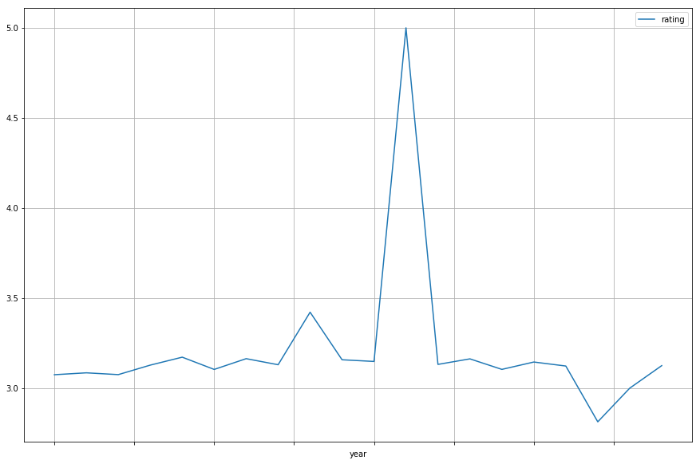

```python
yearly_average[-20:].plot(x='year', y='rating', figsize=(15,10), grid=True)
```

Do some years look better for the boxoffice movies than others?  
Does any data point seem like an outlier in some sense?